# Taylor Swift

Kesha, Vanessa, Peng Chun, Valerie

2024-11-13

```r
# Load packages
library(tidyverse)
library(readxl)
library(lubridate)
library(stringr)
library(ggplot2)
library(viridis)
```

```r
# Load ggradar package
library(ggradar)
```

```r
taylor_album_songs <- readr::read_csv('https://raw.githubusercontent.com/rfordatascience/tidytuesday/master/data/2023/2023-10-17/taylor_album_songs.csv')
```

## Introduction

The Taylor Swift datasets were created by W. Jake Thompson. It provides a comprehensive collection of Taylor Swift’s music, featuring her official albums, singles and EPs. We will mainly explore the first dataset, taylor_album_songs, which includes many numerical audio variables from Spotify for all her songs from her studio albums. We will focus on the variables - album_name, energy, danceability, acousticness, valence, key_mode and duration_ms. The album_name variable labels the album names. The variables energy, danceability, acousticness and valence are all Spotify ratings. The ratings vary from 0 to 1 with 0 being the least and 1 being the most in terms of the respective variable. Additionally, the key_mode variable is the key of the song. Lastly, the duration_ms tells us the duration of the song. The datasets allow for an in-depth exploration of Taylor Swift’s music and evolution.

Our group will explore the question, “How has the style of Taylor Swift’s songs evolved across her career eras?” We will mainly explore the dataset, taylor_album_songs. We will explore the musical characteristics and duration of her songs to uncover patterns and insights that have shaped and reflected her musical journey. We define career eras as the chronological order in which Taylor Swift’s albums were originally released.

## Data Cleaning & Summary

```r
eras_order <- c("Taylor Swift", "Fearless (Taylor's Version)", "Speak Now", "Red (Taylor's Version)", "1989", "reputation", "Lover", "folklore", "evermore", "Midnights")
```

```r
taylor_album_songs <- taylor_album_songs %>%
  select(album_name, energy, danceability, acousticness, valence,key_mode, duration_ms) %>%
  drop_na() %>%
  distinct() %>%
  mutate(album_name=factor(album_name, levels = eras_order)) %>%
  arrange(album_name)

glimpse(taylor_album_songs)
```

```
## Rows: 191
## Columns: 7
## $ album_name   <fct> Taylor Swift, Taylor Swift, Taylor Swift, Taylor Swift, T…
## $ energy       <dbl> 0.491, 0.877, 0.417, 0.777, 0.482, 0.805, 0.578, 0.629, 0…
## $ danceability <dbl> 0.580, 0.658, 0.621, 0.576, 0.418, 0.589, 0.479, 0.594, 0…
## $ acousticness <dbl> 0.57500, 0.17300, 0.28800, 0.05100, 0.21700, 0.00491, 0.5…
## $ valence      <dbl> 0.425, 0.821, 0.289, 0.428, 0.261, 0.591, 0.192, 0.504, 0…
## $ key_mode     <chr> "C major", "G major", "A# major", "A major", "F major", "…
## $ duration_ms  <dbl> 232107, 173067, 203040, 199200, 239013, 207107, 248107, 2…
```

The cleaned dataset focuses only on selected columns, album_name, energy, key_mode, acousticness, danceability, valence, duration_ms, removes any NAs and duplicated rows (if any) to avoid misleading and incorrect data interpretations and arranges the albums according to the chronological eras order.

Here, we defined the eras order using eras_order, a vector of Taylor Swift’s albums arranged based on the chronological order in which the **original** albums were released, instead of just ordering by the album release date (album_release) given in the dataset.

This is as in the dataset, while most are her original albums, the albums “Fearless (Taylor’s version)” and “Red (Taylor’s version)” are her re-released versions, where most of the songs are the same songs in the original album - just re-recorded so that she owns the new version - as well as some additional songs she did not release at the time the original album was released but was still made during that time. Since the songs were made back in 2008 and 2012 respectively, the musical style is from those years, and not 2021 when they were re-recorded. Thus, since we are analysing Taylor’s song style evolution rather than the technical differences of the re-recordings, we arranged them by their original release date, placing them 2nd and 4th respectively, instead of by the re-release date in 2021 which would set them back in 8th and 9th respectively instead (Fitzgerald, 2024).

This ensures that when the albums are displayed on the x-axis of the plot, they accurately reflect her musical evolution over the years.

## Visualization 1:

Visualization 1 is a line plot with points for the average song duration for each era.

Dataset used: taylor_album_songs; It contains information about each song in her various albums, including song duration (duration_ms) in milliseconds and album name (album_name).

Variables used: album_name, to get the album names (eras) duration_ms, to get the average song duration for each era

A line plot with points is ideal for this visualization because:  
1. A line plot inherently suggests a progression over time, thus making it well-suited to show the changes in average song duration across Taylor Swift’s eras.  
2. By connecting the points with lines, the rise and fall of average song durations becomes more obvious.  
3. The points on the line plot emphasize each individual album, making it easy to see the average song duration for each one. Without points, the specific duration for each album might be less clear, and individual album differences would be harder to distinguish.

```r
avg_duration_album <- taylor_album_songs %>%
  mutate(album_name = factor(album_name, levels = eras_order)) %>%
  # Convert album_name into a factor and ordering it according to eras_order will allow the plot to follow Taylor Swift’s discography sequence.
  group_by(album_name) %>%
  # Group by album_name groups the data by each album.
  summarise(avg_duration = mean(duration_ms/60000, na.rm = TRUE))
  #  Calculate the average song duration for each album, by converting milliseconds to minutes (divide duration_ms by 60000), and na.rm = TRUE removes any missing values during the calculation.
```

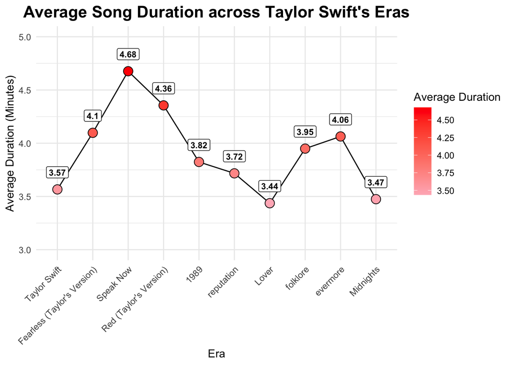

```r
ggplot(avg_duration_album, aes(x = album_name, y = avg_duration, group = 1)) +
  geom_line() +
  geom_point(aes(fill = avg_duration), size = 4, shape = 21, color = "black") +
  # line plot with points, with album_name on the x axis, and avg_duration on the y-axis.
  scale_y_continuous(limits = c(3,5)) +
  # Set the y-axis limits to focus on average song durations between 3 and 5 minutes.
  scale_fill_gradient(low = "lightpink", high = "red", name = "Average Duration") +
  # Use a colour gradient for the points, where lighter shades indicate shorter average durations and darker shades indicate higher average durations.
  labs(title = "Average Song Duration across Taylor Swift's Eras",
       x = "Era",
       y = "Average Duration (Minutes)") +
  geom_label(aes(label = round(avg_duration, 2)), vjust = -1, size = 3, fontface = "bold") +
  # Display each album’s average duration above the points to enhance readability.
  theme_minimal() +
  theme(plot.title = element_text(hjust = 0.5, face = "bold", size = 16),
        axis.text.x = element_text(angle = 45, hjust = 1)) # Angle x-axis labels for better readability.
```

## Visualization 2:

- Create genre groupings with slight adjustments to the data handling

```r
taylor_data <- taylor_album_songs %>%
  mutate(
    # Add a small jitter to values to prevent exact overlaps
    danceability = danceability + runif(n(), 0, 0.01),
    energy = energy + runif(n(), 0, 0.01),
    acousticness = acousticness + runif(n(), 0, 0.01),
    valence = valence + runif(n(), 0, 0.01),
    # Clamp values to ensure they stay within 0-1
    across(c(danceability, energy, acousticness, valence),
           ~pmax(0, pmin(1, .))),
    genre = case_when(
      album_name %in% c("Taylor Swift", "Fearless (Taylor's Version)") ~ "Country",
      album_name %in% c("Speak Now", "Red (Taylor's Version)", "1989", "reputation", "Lover") ~ "Pop Transition",
      album_name %in% c("folklore", "evermore") ~ "Alternative",
      album_name == "Midnights" ~ "Modern",
      TRUE ~ "Other"
    )
  ) %>%
  select(genre, danceability, energy, acousticness, valence) %>%
  na.omit()
```

- Calculate mean values

```r
era_means <- taylor_data %>%
  group_by(genre) %>%
  summarise(across(c(danceability, energy, acousticness, valence),
                  ~mean(., na.rm = TRUE))) %>%
  # Ensure all values are positive
  mutate(across(-genre, abs))
```

- Reshape data for faceted plotting

```r
era_means_long <- era_means %>%
  pivot_longer(
    cols = -genre,
    names_to = "characteristic",
    values_to = "value"
  )
```

- Create the visualization

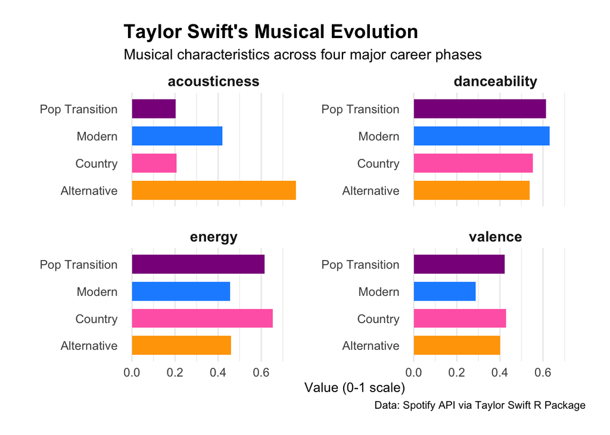

```r
ggplot(era_means_long, aes(x = genre, y = value, fill = genre)) +
  geom_bar(stat = "identity", width = 0.7) +
  facet_wrap(~characteristic, scales = "free_y", ncol = 2) +
  scale_fill_manual(values = c(
    "Alternative" = "#FFA500",
    "Country" = "#FF69B4",
    "Modern" = "#1E90FF",
    "Pop Transition" = "#8B008B"
  )) +
  coord_flip() +
  labs(
    title = "Taylor Swift's Musical Evolution",
    subtitle = "Musical characteristics across four major career phases",
    y = "Value (0-1 scale)",
    x = "",
    caption = "Data: Spotify API via Taylor Swift R Package"
  ) +
  theme_minimal() +
  theme(
    plot.title = element_text(size = 16, face = "bold"),
    plot.subtitle = element_text(size = 12),
    axis.text = element_text(size = 10),
    strip.text = element_text(size = 12, face = "bold"),
    legend.position = "none",
    panel.grid.major.y = element_blank(),
    panel.spacing = unit(1, "lines"),
    plot.margin = margin(t = 20, r = 20, b = 20, l = 20)
  )
```

## Visualization 3:

Visualization 3 focuses on finding out how the key mode of Taylor Swift’s songs evolved through her eras. The variables used are:  
1. album_name, to get the Taylor Swift Era. 2. key_mode, to get the key_mode of each song per Era album.

Here, a heat map is ideal in answering the question as:  
1. Both variables are categorical.  
2. It is a relatively large data set with key_mode having 18 different categories.  
3. By using a color gradient, it is easy and intuitive for viewers to understand and compare the differences in use of key modes across the Eras, with the added bonus of making the large amount of data more visually appealing.

Additionally, viridis color scheme is used to increase accessibility by accounting for colorblindness.

Finally, we use percentage of songs per album with that key mode instead of just count of songs to normalize the data.

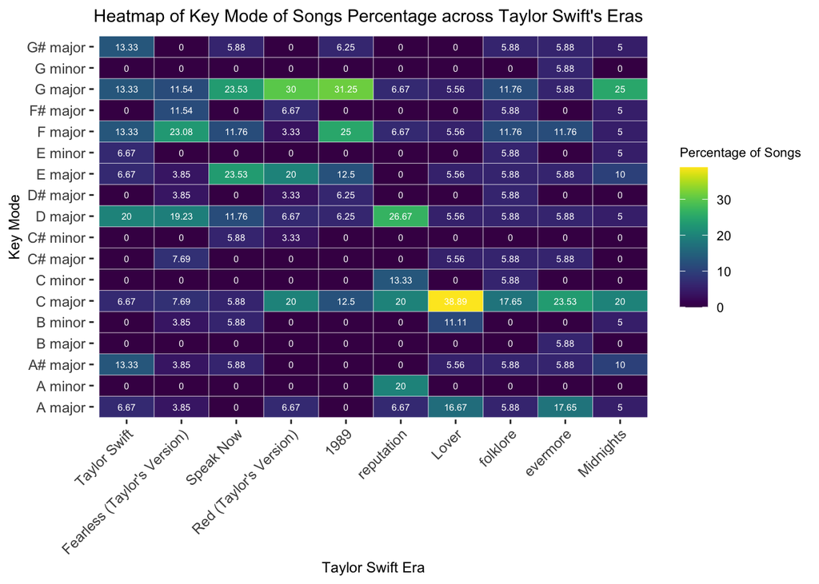

```r
df3 <- taylor_album_songs %>%
  group_by(album_name, key_mode) %>%
  #count songs with each key_mode per album
  summarise(count = length(album_name)) %>%
  ungroup() %>%
  #fill in blank cells
  complete(album_name = eras_order, key_mode, fill = list(count = 0.00)) %>%
  group_by(album_name) %>%
  #get percentage of songs per album with each key_mode
  mutate(keymode_songs_percentage = count/sum(count)*100)

#make sure eras are ordered correctly
df3$album_name <- factor(df3$album_name, levels = eras_order)

ggplot(df3, aes(x=album_name, y=key_mode, fill = keymode_songs_percentage)) +
  geom_tile(color= 'white') +
  geom_text(aes(label = round(keymode_songs_percentage, 2)), size =2, color = 'white') +
  labs(title = "Heatmap of Key Mode of Songs Percentage across Taylor Swift's Eras",
       x = "Taylor Swift Era",
       y = "Key Mode",
       fill = "Percentage of Songs") +
  scale_fill_viridis(option="O") + #viridis to account for colorblindness
  theme(axis.text.x = element_text(angle = 45, hjust = 1),
        title = element_text(size=9),
        legend.text = element_text(size = 8),
        legend.title = element_text(size = 8),
        panel.background = element_blank(),
        panel.grid.major = element_blank(),
        panel.grid.minor = element_blank())
```

## Discussion

### Visualization 1 Analysis

Visualization 1 shows a chronological view of the evolution of Taylor Swift’s music in terms of the average song duration for each album. By arranging her albums in original release order on the x-axis and plotting the average song duration on the y-axis, we can observe trends and shifts in her music over time.

The use of a colour gradient for the points visually emphasises changes in the average song duration, with darker shades representing higher averages. This intuitive colour gradient allows viewers to quickly identify albums with longer or shorter average song durations. Furthermore, adding labels for each point enhances readability, allowing the viewer to see specific average song durations. The rotated x-axis labels also ensure clarity in reading the various albums, especially since some of the albums are lengthy.

### Visualization 3 Analysis

For Visualization 3, we used a heat map (refer to the para under ‘Visualisation 3’ for why we chose a heat map) with the main aim of finding out how the key mode of Taylor Swift’s songs changed through her eras.

Analysis: From the heat map, it can be seen that Taylor Swift generally used **3 main key modes** the most across her eras- **D major, G major and C major**. This is evident in how her earlier eras of ‘Taylor Swift’ and ‘Fearless (Taylor’s Version)’ saw relatively high usage of D major (20% and 19.23% of songs respectively). Her next 3 eras had G major as the highest key mode of songs percentage in each album - 23.53%, 30% and 31.25% of songs for ‘Speak Now’, ‘Red (Taylor’s Version)’ and ‘1989’ respectively; though it should be noted that there was a tie for ‘Speak Now’, where 23.53% of songs in said era used E major too. Following which, her ‘reputation’ era saw a return to D major, with 26.67% of songs. Her later eras then usually used C major the most, with relatively high percentages of 38.89%, 17.65%, 23.53% and 20% for the ‘Lover’, ‘folklore’, ‘evermore’ and ‘Midnights’ eras respectively, though the ‘Midnights’ era also saw a return to G major with 25% of songs.

Generally, her **least used key mode** is **G minor** and **B major**, with both only appearing once in the ‘evermore’ era, at a relatively low percentage of 5.88% each (equivalent to 1 song).

Taylor’s use of **minor key modes** also remains relatively **constant and low**, with only 1-2 used per era. In fact, ‘1989’ used no minor key modes at all.

### Overall Pattern

Overall, Taylor Swift’s songs have generally become shorter, less energetic and slightly more emotionally-’negative’ (e.g. sadder, angrier) across her eras. In terms of the technical aspect, the key mode of her songs has changed from D major initially, to G major and finally, C major in later eras.

## References

1. Data source: https://github.com/rfordatascience/tidytuesday/blob/master/data/2023/2023-10-17/readme.md
2. Complete a data frame with missing combinations of data. tidyr. (n.d.). https://tidyr.tidyverse.org/reference/complete.html
3. Fitzgerald, T. (2024, July 10). Every Taylor Swift album in order of release. Forbes. https://www.forbes.com/sites/entertainment/article/taylor-swift-albums/
4. GeeksforGeeks. (2023, June 8). Create Heatmap in R Using ggplot2. https://www.geeksforgeeks.org/create-heatmap-in-r-using-ggplot2/
5. Rudis, B., Ross, N., & Garnier, S. (2024, January 28). Introduction to the viridis color maps. https://cran.r-project.org/web/packages/viridis/vignettes/intro-to-viridis.html/